# 海湾主权财富基金与AI资本转向，2023-2026

海湾主权资本如何重整以攀爬AI价值链，以及这笔赌注是否划算

作者

Gen

发布于

2026年5月28日

摘要

2023至2026年间，海湾合作委员会的主权财富基金从被动的全球投资者，转变为人工智能基础设施的创建者与运营者。它们设立国家冠军企业，签约数吉瓦算力，争取到先进芯片配额，并在前沿模型实验室中买入少数股权。仅2025年，主权投资者就向AI与数字化投入约660亿美元，其中中东基金领跑全球。

本报告勾勒这场转向，并追问它是否划算。一套协同的机构栈，沙特的Humain、阿布扎比的MGX、卡塔尔投资局的直接持仓，将资本沿着从能源、算力、芯片、模型到应用的AI价值链向上输送。然而这一攀升存在天花板。海湾可以拥有栈的底层，但芯片层与前沿模型层受制于域外设定的条款，其财务逻辑更多建立在战略期权之上，而非已证实的回报。

结论是有条件的。这场转向作为战略与多元化是站得住脚的，作为投资却尚未被证实，其回报取决于五个变量，其中以芯片获取的稳定性与油价为首，而这些海湾仅能部分掌控。

**关键词**：海湾主权财富基金 | 沙特公共投资基金 | MGX | AI基础设施 | 数据中心 | 愿景2030 | 算力价值链

# 1 引言：海湾的24个月转向

这份雄心是公开宣示的。沙特新设的国家AI公司提出要成为继美国与中国之后全球第三大AI提供方；阿联酋发布了以2031年领先为目标的国家AI战略，并揭幕了一座被称为美国境外最大此类项目的五吉瓦数据中心园区 (CNBC 2025年b; DataCenterDynamics 2025年)。这些不是财务投资者多元化配置时的谨慎措辞，而是产业政策的语言，且以主权资产负债表来推进。

图 1 标出了这些里程碑。最引人注目的是时间的压缩。让这一切成为可能的机构、交易与政策框架，都在2023至2026年这一窗口内成形，而这一窗口短到这套战略及其执行至今仍在实时展开。

图 1: 从ChatGPT到Blackwell：海湾主权AI转向压缩在约24个月内

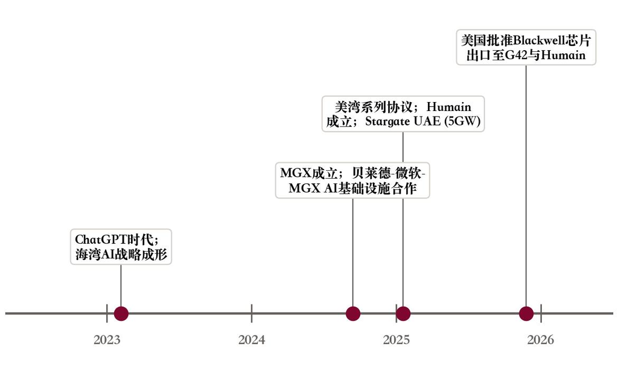

*来源：Global SWF；英伟达；Axios；CNBC；公司公告 | 注：2023-2025年精选里程碑，日期约至公告月份。*

## 1.1 论证脉络与论断的边界

本报告分五步展开论证。第一步是解剖：海湾投入了多少资本、有多快、通过什么机构、以及在怎样的财政背景之下。第二步是价值链：这些基金究竟在逐层买入什么，从底层的能源到顶层的应用。第三步是约束：为何先进芯片的获取，一个由域外设定的监管变量，限制了主权资本能攀爬的高度。第四步是裁决，权衡战略理由与财务风险。第五步是展望，即将决定这笔赌注能否回本的变量。这一结构是有意的：描述性章节为后面的判断赢得依据。

有两条边界值得在开篇说明。本报告不构建原创财务模型，也不估算基金层面的AI回报，因为这些基金并不披露；凡涉及回报，均为定性判断，而非可量化的数字。本报告还自始至终区分已宣布的承诺，这类数字繁多且抢眼，与已落实部署的资本，后者是更小、更慢、更难界定的数字。凡证据只支持方向性判断之处，文中直说，而不把推断包装成事实。许多数字，尤其是基金资产与单年部署总额，来自口径各异的数据聚合机构与媒体报道；这些差异被标注，而非被抹平。

# 2 转向的解剖：投了多少、多快、来自何处

## 2.1 三只万亿美元基金，支撑起逾3.2万亿美元的资本底座

转向背后的资本底座，是世界上最大的可投资金池之一，这是海湾能以如此速度行动的首要原因。截至2025年年中，三只海湾基金各自跨过1万亿美元门槛：沙特公共投资基金约1.15万亿美元，阿布扎比投资局1.11万亿美元，科威特投资局略超1万亿美元 (Global SWF 2025年)。再加上卡塔尔投资局约4450亿美元、穆巴达拉3030亿美元、ADQ约2000亿美元，六只主要海湾基金合计管理逾3.2万亿美元。按Global SWF的口径，2025年最大的七只海湾基金占全球国有投资者部署资本的43%，为历史最高 (Global SWF 2026年)。

图 2 给出六者的排名。这种集中度对后文很关键。少数几家机构，各自的资产负债表可与最大的私人资产管理公司比肩，能在一个董事会周期内就投入一个新资产类别，而无需私人资本所受的募资、达成共识或赎回压力的约束。当PIF决定设立一家国家AI公司时，它不必先去募一只基金。

图 2: 三只海湾主权基金资产已超1万亿美元，六只合计超3.2万亿美元

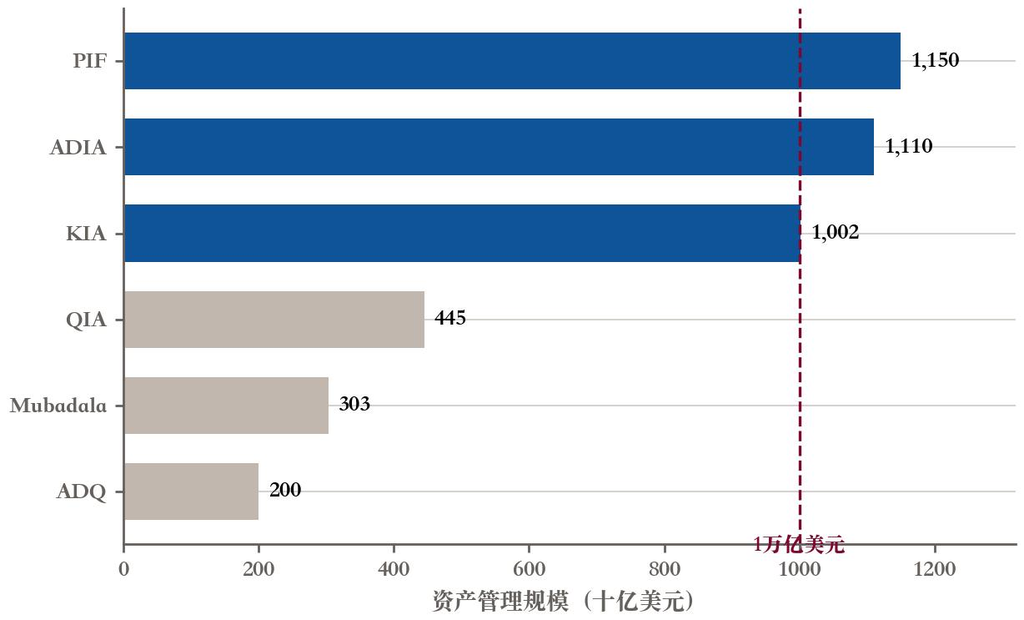

*来源：Global SWF排名，2025年7月（经Gulf Business、Zawya） | 注：PIF=沙特公共投资基金；ADIA=阿布扎比投资局；KIA=科威特投资局；QIA=卡塔尔投资局。*

这些基金并非可以互换，其差异塑造了这场转向。ADIA与KIA最为老牌、最为保守，是外部盈余的长期管理者，组合全球分散、以被动为主。穆巴达拉与ADQ更偏发展导向、也活跃得多，是阿布扎比用作经济战略的工具。PIF处在最激进的一端，肩负在愿景2030之下于沙特境内培育新产业的明确国内使命。这一光谱解释了为何AI转向通过激进型载体，即PIF、穆巴达拉、ADQ与QIA推进，而非通过那两家被动巨头：打造国家冠军是发展使命，而非储备管理任务。

公共投资基金最生动地展现了这一轨迹。其资产在十年间增长约七倍，从2015年估计的1600亿美元升至2025年约1.15万亿美元，期间沙特将储备与阿美股权转入其资产负债表，再投入境内超级工程与全球投资 (Global SWF 2025年)。图 3 显示了这一攀升。2024与2025年的端点为确切值；中间年份为来自聚合机构与披露的估算，并已如此标注。PIF于2025年4月将其2030年资产目标上调至约2.67万亿美元，高于此前约2万亿美元的目标，这将使它跻身全球最大主权资本池之列 (The National 2025年)；它能否达到这一数字，在很大程度上取决于本章后文考察的油价与财政背景。

图 3: PIF资产十年间增长约七倍，至约1.15万亿美元

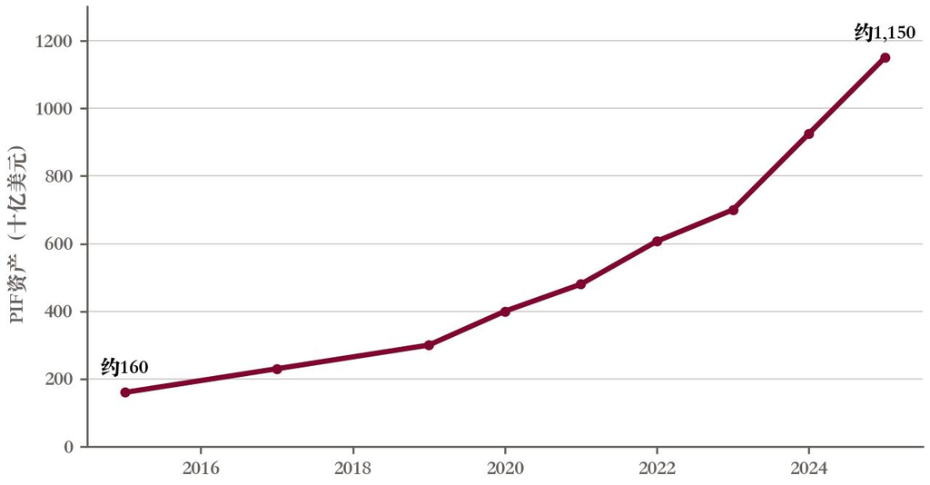

*来源：Global SWF、SWFI及PIF披露；中间年份为估算 | 注：2024-2025年端点为确切值；2015-2023年为基于聚合机构与媒体的估算。*

## 2.2 一年内投入660亿美元主权资本、由海湾领跑

具体投向AI的资金是晚近且集中的，这是转向的第二个标志性特征。Global SWF估计，2025年国有投资者向AI与数字化投入约660亿美元，这一年该类别从机会型配置转为公开宣示的战略优先 (Global SWF 2026年)。中东领跑全球。穆巴达拉投入129亿美元，科威特投资局60亿美元，卡塔尔投资局40亿美元，是当年全球最大的三笔单一基金投入。

图 4 显示了领跑者。两点口径说明随附于此数字。其一，口径是AI与数字化合并，比纯AI更宽，会把相邻的科技支出一并纳入；把它当作纯AI部署的比较会高估AI份额。其二，它衡量的是单一年度的流量而非累计敞口，因此反映的是2025年的节奏，而非海湾AI资产的总存量，后者更大且更难界定。每当跨来源比较主权AI数字时，这两点都需放在心上，因为聚合机构与基金自身对该类别的定义各不相同。

图 4: 2025年穆巴达拉以129亿美元AI与数字化投资领跑中东主权基金

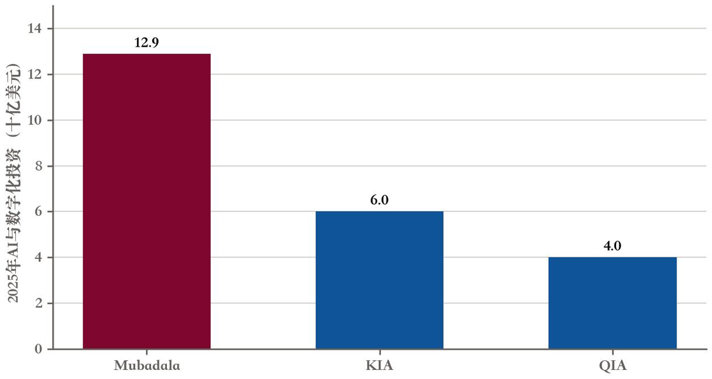

*来源：Global SWF 2026年报（经Bloomberg、Gulf News） | 注：2025年全球主权投资者向AI与数字化投入约660亿美元；此处为中东三大领先基金。*

转向的速度与其规模同样值得注意。行业追踪机构报告，流入AI公司的中东主权资本在前一年内增长数倍，且大部分活动集中在2024年之后，随着这些基金设立专门载体并签署框架协议 (Global SWF 2026年)。这并非随估值上行而逐步累积的配置；一旦下章考察的机构机器就位，它便骤然提速。这些基金没有等到看清AI如何演变才投入，而是在这一技术及其经济性尚未确立之时就出手，而这恰恰使这笔赌注成为对未来的期权，而非在一项已被证实业务中的头寸。

## 2.3 为什么是现在：更薄的财政缓冲提高了赌注，而非降低

这场转向正发生在海湾传统缓冲，即石油收入变薄之际，时机并非巧合。沙特从2022年约GDP的2.2%的财政盈余，转为2024年2.5%的赤字，IMF预测随着油价走软与超级工程支出持续，2025年赤字将扩大至约4% (IMF 2025年)。经常账户讲述着同样的故事，从2022年逾GDP的12%的盈余，转为2024年的小幅赤字。图 5 显示了财政路径，包括IMF的油价负向压力情景，在该情景下总体赤字将于2025年达到GDP的6.7%、2026年超过10%。

图 5: 沙特由2022年盈余转为持续赤字；油价冲击下将突破-10%

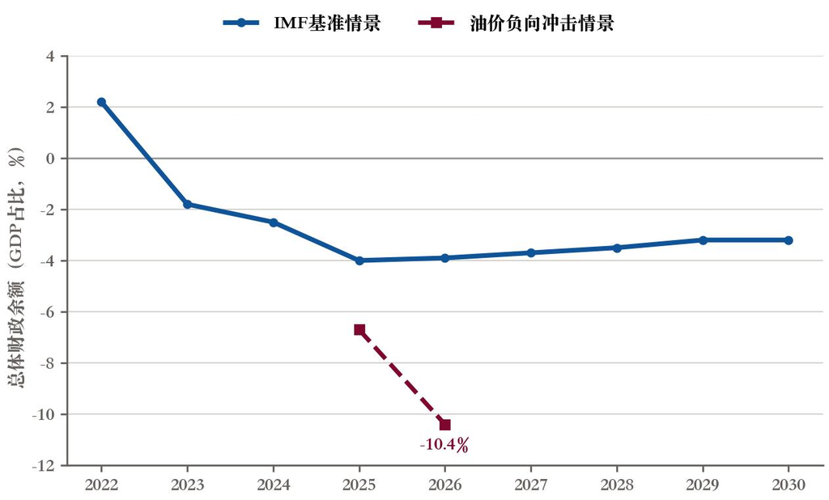

*来源：IMF沙特2025年第四条磋商报告，表1与附录VII | 注：中央政府净借贷；冲击情景取自IMF油价负向压力测试。*

这一压力是结构性而非周期性的，这正是它与一项跨数十年战略相关之处。IMF预测沙特石油出口价将于2025年回落至约70美元/桶，并在2030年前维持在67至68美元附近，明显低于王国的财政盈亏平衡价 (IMF 2025年)。对该盈亏平衡价的估计集中在预算口径约94美元/桶，计入PIF的国内支出后升至约101至111美元，差异取决于是否把通过PIF推进的超级工程支出计入 (Emirates NBD Research 2025年)。图 6 把预测油价与该盈亏平衡区间并置。两条线之间持续的缺口，正是多元化最终意在弥合的结构性赤字。

图 6: 预测油价在2030年前持续低于沙特财政盈亏平衡价

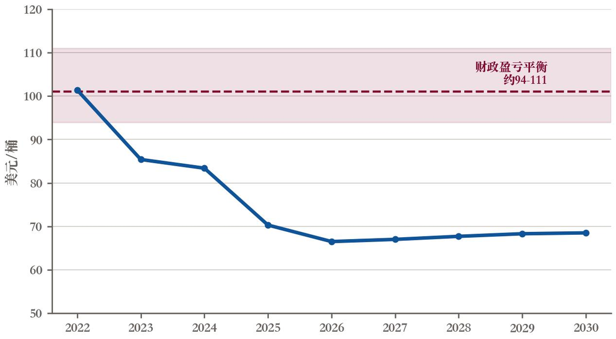

*来源：IMF沙特2025年第四条磋商报告表1（油价）；Emirates NBD、Bloomberg Economics（盈亏平衡） | 注：盈亏平衡区间预算口径约94美元/桶，计入PIF国内支出约111美元；Emirates NBD估2025年约101美元。*

油价走软提高了多元化的紧迫性，而非缓解它，这正是转向时机的反直觉逻辑所在。倘若石油收入在数十年内看来稳固，海湾本可从容地慢慢多元化。正因长期收入基础看来更弱，今日大举支出以另建一套收入基础的理由反而更强，尽管同样走软的油价收紧了为支出筹资的预算。IMF自己的判断是，多元化确有真实势头，2024年非石油实际GDP增长4.5%，但财政路径如今取决于油价回升或非石油收入的持续动员 (IMF 2025年)。AI是多元化迫切性最新、也是迄今资本最密集的体现。

## 2.4 筹资逻辑：石油仍在埋单，PIF是引擎

就目前而言，仍是石油在为这一转型筹资，这是AI雄心之下令人不安的算术。2024年沙特中央政府石油收入约7570亿里亚尔，非石油收入5020亿里亚尔，按IMF预测，到2030年两条线几近趋同，分别约为6900亿与6880亿里亚尔 (IMF 2025年)。图 7 显示了这一趋同。它把多元化的故事压缩进一张图：非石油收入在稳步追赶，但在AI赌注落子的整个时期，仍是石油在挑更重的担子。新经济在很大程度上由旧经济筹资。

图 7: 非石油收入到2030年几近追平石油，但今日仍靠石油为多元化筹资

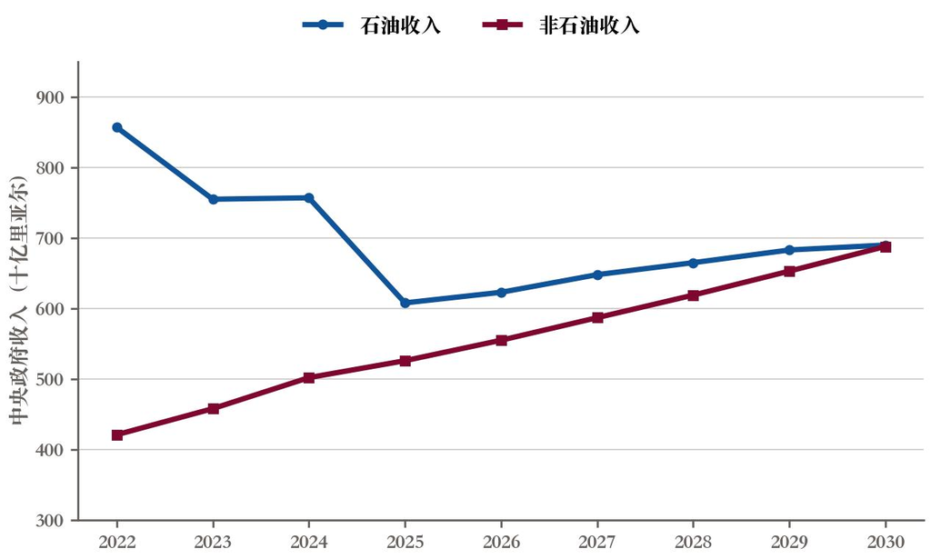

*来源：IMF沙特2025年第四条磋商报告表2（预算中央政府运营） | 注：2025年起为IMF工作人员预测；数据与中央政府总收入对账一致。*

PIF是境内建设的引擎。IMF预计它每年至少向沙特经济注入400亿美元，用于为NEOM等超级工程、以及日益增多的AI基础设施筹资 (IMF 2025年)。关键在于，这部分支出大多走PIF自身的资产负债表，而非政府预算，这正是为何预算口径的盈亏平衡数字低估了王国真正需要的油价；计入PIF支出的盈亏平衡价要高得多。这一安排给了国家灵活性，但也意味着AI建设暴露于PIF自身的筹资能力，而后者取决于资产表现、来自阿美的分红，以及该基金的举债能力。

其中部分筹资来自举债。沙特中央政府总债务预计将从2022年GDP的21%升至2030年约41%，PIF自身也已成为债券与银团贷款的常规发行方 (IMF 2025年)。图 8 显示了这一攀升。以全球标准衡量，债务水平仍低，王国也保有可观缓冲，因此这并非偿付能力之忧。但方向毫不含糊：海湾正部分以举债为其未来筹资，且背景是更软的油价，这就抬高了新投资最终所产生回报的赌注。以低息举债去建造不产生收益的资产，与为生产性产能筹资的举债，是两回事，而AI建设最终属于哪一种，正是本报告反复回到的悬而未决之问。

图 8: 沙特部分以举债支撑转向：总债务到2030年近乎翻倍至GDP的40.6%

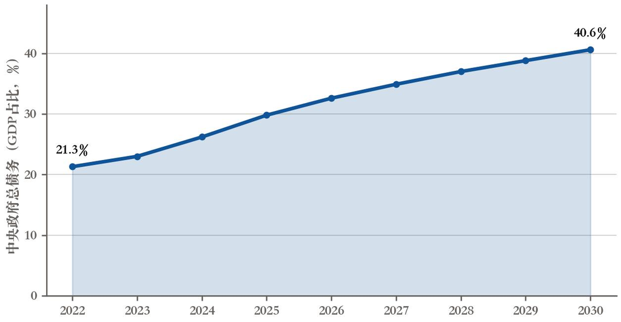

*来源：IMF沙特2025年第四条磋商报告表2（备忘项） | 注：IMF工作人员预测；债务以全球标准衡量仍低，但正上升以为赤字与超级工程融资。*

# 3 载体：一套全新的主权AI机构栈

## 3.1 每个海湾资本都打造了专属的AI冠军

这场转向是机构性的，而不仅是财务性的，这正是它区别于资产配置倾斜之处。这些海湾资本没有把AI投资塞进既有的综合组合，而是各自打造了拥有自身使命、领导层与合作网络的专属载体。图 9 给出这套栈的图谱。在沙特，PIF创建了全栈AI冠军Humain，并另设一只AI投资基金；在阿布扎比，穆巴达拉与AI运营商G42创建了全球AI基础设施投资者MGX，与G42作为该酋长国运营臂膀的角色互补；在卡塔尔，QIA运作的是一本更直接的持股与合资账本，而非单一品牌载体。共同的特征是协同。这些是国家战略的工具，意在集中决策、并向全球伙伴呈现单一对手方，而非一盘零散的机会型交易。

图 9: 每个海湾资本都打造了专属AI载体：Humain、MGX与QIA的直接持仓

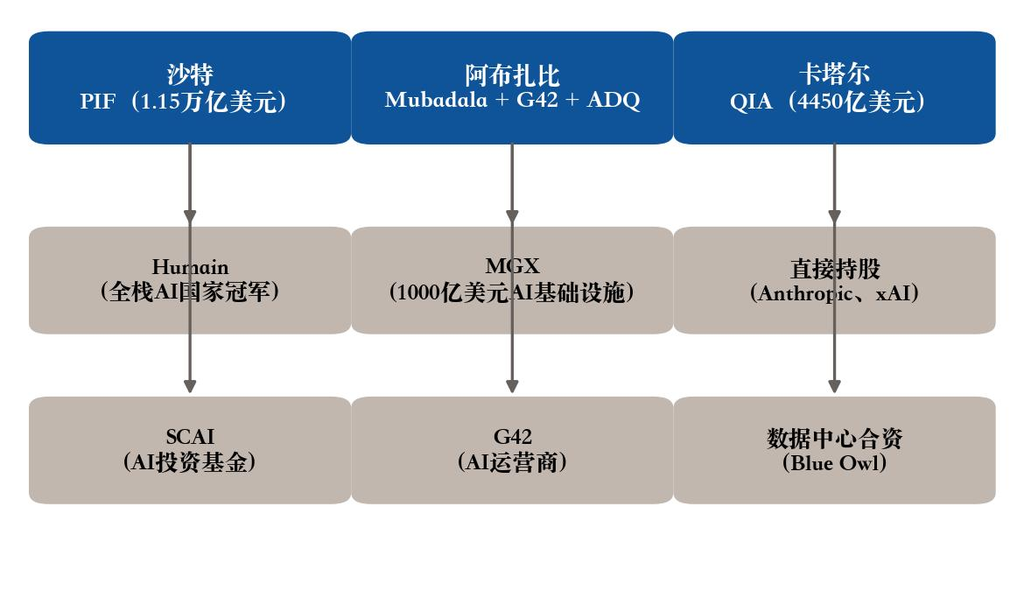

*来源：PIF、Mubadala、G42、MGX与QIA披露 | 注：是协同的机构栈，而非零散交易；资产规模据Global SWF，2025年7月。*

## 3.2 沙特：Humain作为全栈国家冠军

Humain是这些载体中最雄心勃勃的，也是全栈战略最清晰的宣示。它由PIF于2025年5月在首席执行官塔里克·阿明（Tareq Amin）领导下创立，提出要在王国境内掌控整条AI价值链，从数据中心、芯片到模型与应用，并明确以成为继美国与中国之后全球第三大AI提供方为目标 (CNBC 2025年b)。这一定位本身意味深长：不是AI的国家用户，而是国家提供方，向全球市场出售算力与服务。

数月之内，Humain就签下了一连串引人注目的算力协议。它与英伟达合作，初期建设500兆瓦、由1.8万颗其最先进芯片驱动的算力，五年内将增至数十万颗；与AMD和思科达成一吉瓦合资；与xAI约定500兆瓦项目；与AWS设立50亿美元的「AI Zone」；部署Groq芯片用于推理；并与数据中心运营商AirTrunk签下约30亿美元合作，外加一笔为250兆瓦容量配套的12亿美元融资 (NVIDIA 2025年; Semafor 2025年; DataCenterDynamics 2026年)。合作方之广本身就是战略，横跨英伟达、AMD、高通、思科、AWS、xAI与Groq：Humain在组建一个供应商生态，而非押注单一供应商。

图 10 给出以容量计价的交易规模，在该载体头几个月里合计签约约两吉瓦。需求以一种印证商业逻辑的方式跑在了供给之前：到2025年8月，Humain报告其规划容量已经售罄，且客户中仅一小部分来自境内 (Semafor 2025年)。这一细节很重要。一项主要面向出口、向全球客户出租沙特算力的建设，比一项仅按内部需求规模设定的建设，是更可信的多元化布局，因为它带来外汇收入，而非仅仅替代进口。它也使Humain暴露于全球算力定价与产能过剩之风险，这些主题将在裁决一章展开。

图 10: Humain在2025年5月成立后数月内签约约2.0GW算力

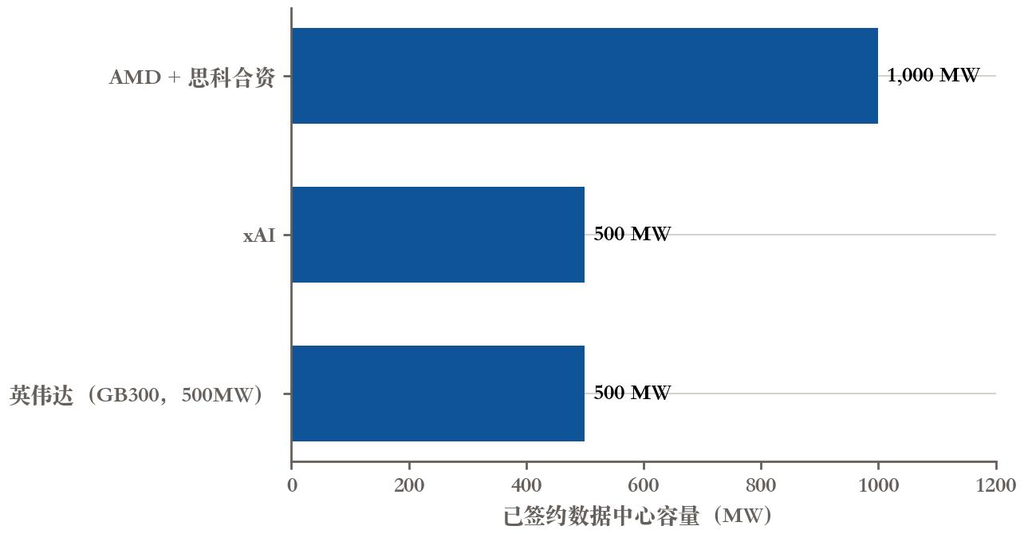

*来源：英伟达；CNBC；DataCenterDynamics；Semafor | 注：仅含以容量计价的交易；Humain另签50亿美元AWS「AI Zone」与约30亿美元AirTrunk合作（容量未披露）。*

## 3.3 阿布扎比：MGX作为千亿美元的全球AI基础设施机器

如果说Humain是面向内部的冠军，MGX就是海湾面向外部的臂膀，也是两者中在国际上更具影响者。它由G42与穆巴达拉于2024年创建，目标管理1000亿美元资产，投资横跨三大支柱：包括数据中心在内的AI基础设施、半导体，以及模型与应用等核心AI技术 (MGX 2025年)。Humain在沙特境内建设，MGX则在全球部署，把阿布扎比定位为全球而不只是本土的AI基础设施出资方。

它的交易清单是所有海湾载体中最具分量的。MGX于2024年底与贝莱德、微软共同加入「全球AI基础设施投资伙伴关系」，该载体瞄准数据中心及其电力基础设施；2025年初成为与OpenAI、软银、甲骨文合作的Stargate算力计划的伙伴；并于2025年10月与贝莱德的基础设施臂膀共同主导了对Aligned数据中心的400亿美元收购，被报道为有记录以来最大的数据中心交易 (CNBC 2025年a)。同期它在一笔将OpenAI估值定为5000亿美元的出售中买入二级股权，有报道称MGX正考虑募集250亿至500亿美元以支持进一步投资。其涉猎已从纯AI延伸至相邻科技乃至加密与社交媒体的联合体，这招致一些审视，却也凸显该载体的触角之广。

图 11 把这些与1000亿美元目标并置。该图有意把项目级雄心与已成交交易混排，注释中标明了这一区别，因为把二者混为一谈是对MGX报道中的常见错误。Aligned收购与OpenAI股权是真实、已成交的头寸；1000亿美元目标与Stargate头条则是将在数年间逐步部署的项目级雄心。诚实的解读是：MGX已经以少有私人基础设施投资者能匹敌的规模出手，而其最大的数字仍是远期承诺。

图 11: MGX目标1000亿美元，并主导400亿美元Aligned收购，为迄今最大数据中心交易

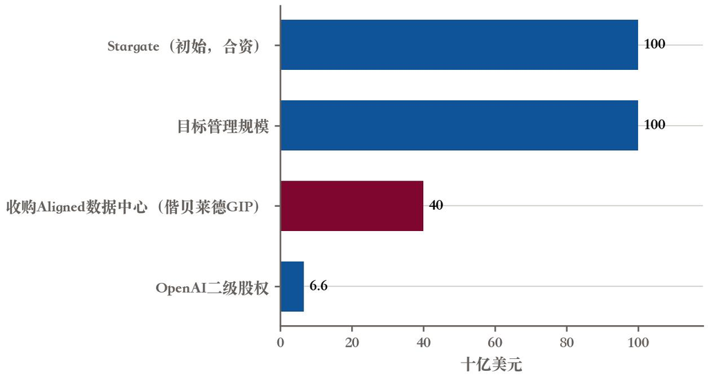

*来源：MGX与Mubadala披露；CNBC；Wamda；Funds Global MENA | 注：目标规模与Stargate为项目级数字；Aligned与OpenAI股权为已成交/二级交易。*

## 3.4 卡塔尔及其余：QIA押注前沿，其他基金有所取舍

较小的基金有所参与但有所取舍，这本身就透露出信心所在。科威特投资局2025年向AI与数字化投入约60亿美元，阿曼投资局与沙特王国控股一同加入了xAI的融资，而巴林的Mumtalakat相对沉静 (Global SWF 2026年)。整体而言，按交易笔数计，穆巴达拉是2025年最活跃的海湾基金，提醒人们即便沙特打造了最显眼的国家冠军，最忙碌的交易者却是阿布扎比而非利雅得。由此浮现的格局是一种分工：沙特建设境内的全栈提供方，阿布扎比为全球基础设施出资并通过G42运营，卡塔尔买入前沿股权，而较小的基金采取选择性的跟投头寸而非领投。

# 4 攀爬价值链：他们在买什么

## 4.1 阶梯：底层是能源，顶层是应用

读懂海湾买入行为最清晰的方式，是把它看作一次攀爬AI价值链的尝试，而这一尝试在某些层成功、在另一些层受阻。图 12 列出五层，从底部的能源与电力，经算力与数据中心、芯片、基础模型，到顶部的应用与服务。海湾在各层的位置截然不同，而这些差异正是本报告核心发现的可视化呈现。它彻底拥有底层，那里廉价天然气、扩张中的太阳能与充裕土地是真实的比较优势。它正在大规模、快速地建设算力层。但芯片层仅是获取，受下章考察的出口规则管制，模型层则是一组少数股权而非控股。这一阶梯的形状，就是论证的形状：海湾拥有底层、租用顶层。

图 12: 海湾拥有AI栈底层、租用顶层；芯片层是受管制的咽喉

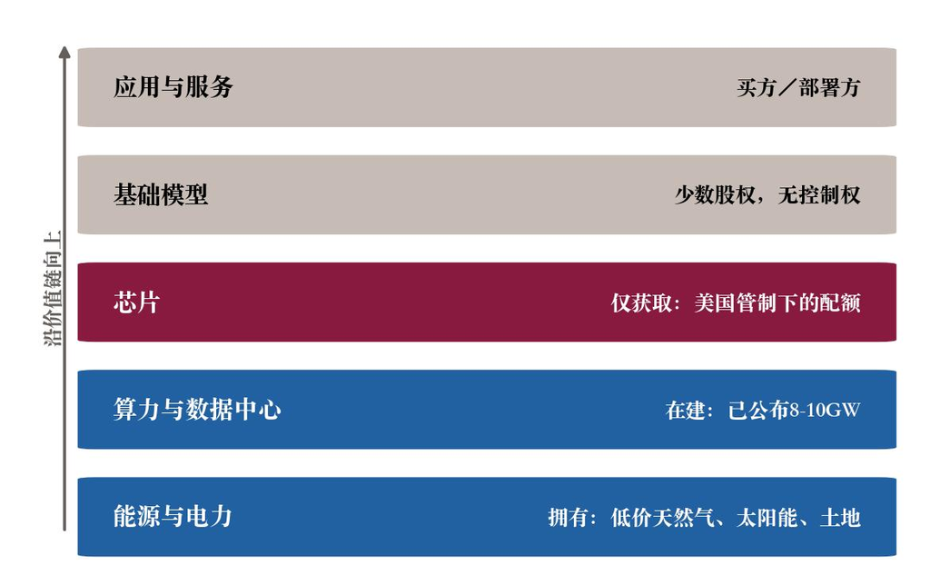

*来源：CSIS；中东研究所；牛津经济研究院；作者框架 | 注：蓝色=海湾可拥有；酒红=受美国出口政策管制；灰色=少数股权／买方地位。*

把算力视为战略资源的框架，在分析文献中日益明确，其中一项有影响的论述认为，倘若算力是新石油，对它的掌控便承载着碳氢曾经承载的战略分量 (CSIS 2025年)。对海湾而言，这一类比有两面性。它在能源端处境良好，历史上在那里握有力量，但这一比较恰恰在最关键之处失灵：石油那一仗，海湾掌控资源；算力这一仗，它掌控能源与土地，却不掌控芯片或模型。因此，弄清阶梯上哪些级是拥有、哪些是租用，是评估整桩事业的钥匙。

## 4.2 能源与算力：把廉价电力变成容量

海湾沿价值链向上的第一步，是把能源优势转化为计算容量，而已公布的规模确实可观。项目包括阿布扎比一座五吉瓦园区，占地约十平方英里，被称为美国境外最大的AI基础设施项目，由G42偕美国超大规模云厂商运营；Humain约六吉瓦的十年目标；以及一座与50亿美元DataVolt协议挂钩的1.5吉瓦NEOM项目 (DataCenterDynamics 2025年)。图 13 给出项目排名。能源是这里真正的优势：数据中心在经济意义上是把电力转化为计算的机器，而海湾能比多数地区更廉价地供应这些电力，并辅以土地与资本。

图 13: 海湾已公布的AI数据中心项目各达5-6GW，远超当下约1GW的在运基数

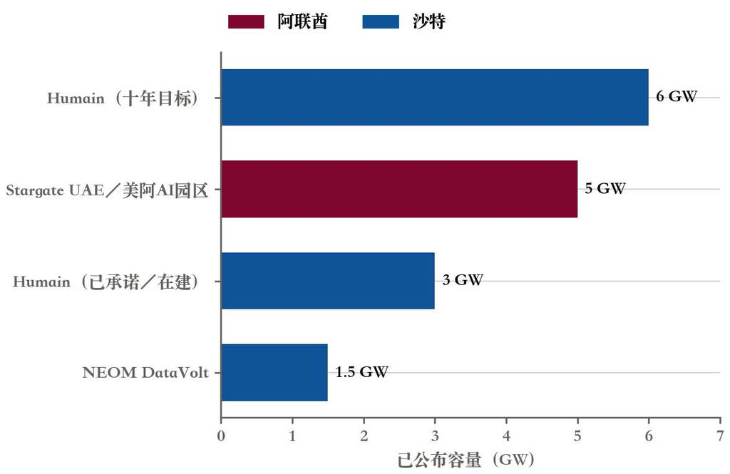

*来源：DataCenterDynamics；Introl；公司公告 | 注：为已公布／目标容量，尚未建成；Humain十年目标与其已承诺／在建部分有重叠。*

公布与建成之间的缺口，是贯穿本章的告诫，而且这一缺口很大。海湾在运的AI数据中心容量在2025年约为一吉瓦，对照已公布与目标的八至十吉瓦管线 (Analysys Mason 2026年)。图 14 显示了这一缺口。Analysys Mason预计2026年海湾对AI数据中心的加速投资将达50至70亿美元，是可观的数字，却只是完全兑现已公布管线所需的一小部分。把公布的数字当作已装机容量，会把建设规模高估近一个数量级，这正是本报告自始至终把已公布容量与在运容量视为不同口径的原因。

图 14: 在运容量（约1GW）与海湾已公布的8-10GW之间存在巨大缺口

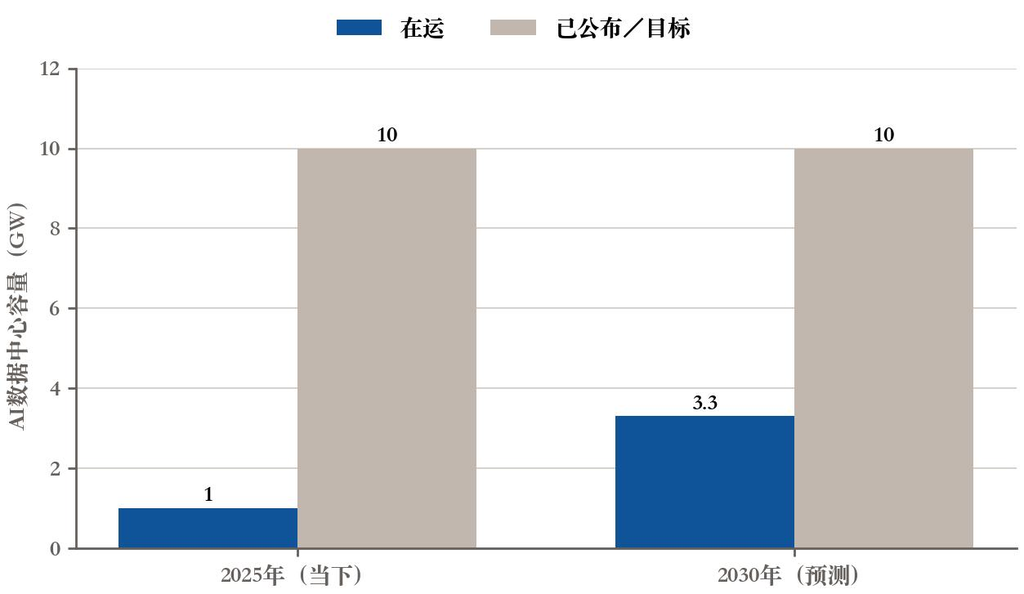

*来源：Analysys Mason；Introl；公司公告（Stargate UAE、Humain、NEOM） | 注：已公布／目标取披露项目管线上限；在运为已装机容量。*

这一建设还撞上了头条吉瓦数字所掩盖的物理极限。大型AI园区对电力与水都极度渴求，而海湾是地球上水资源最紧张的地区之一，这把运营方推向闭环冷却与太阳能，但也引出多吉瓦集群在沙漠气候中可持续性的疑问。能源优势是真实的，却并非无限，而以已公布规模可靠供应电力与冷却的成本，是将决定这些项目是按计划建成、还是被悄然缩减的变量之一。

## 4.3 芯片：买到的是配额，而非制造

这一算力建设运行在海湾造不出的芯片上，而在这里，这些基金买到的是获取权，而非供给。阿联酋争取到一项框架，2025至2027年每年最多获得50万颗英伟达最先进芯片，价值约150亿美元，而Humain首批为1.8万颗、后续更多 (CNBC 2025年c; NVIDIA 2025年)。图 15 对比这两个量。阿联酋年度配额与Humain初批之间的规模差异是真实的，但不及二者的共性重要：两者都是对域外制造芯片的配额，按域外设定的条款授予，而非本土制造。

图 15: 阿联酋年度英伟达配额远超Humain首批，但两者都是获取而非自供

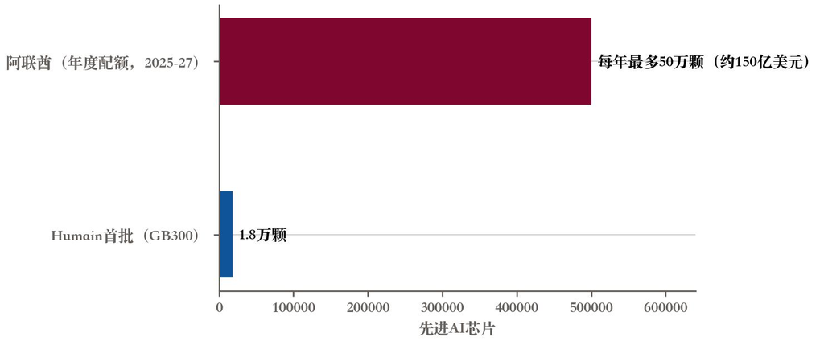

*来源：英伟达；CNBC；Axios | 注：阿联酋2025-27年每年最多50万颗先进英伟达芯片（约150亿美元）；Humain首批1.8万颗GB300，后续更多；均非本土制造。*

这是拥有终止、依赖开始的一级。设计或制造尖端AI加速器，需要一条从设计工具到流片的供应链，而这是任何海湾国家都不具备、且即便手握资本也要花费多年与数百亿美元才能建成的。海湾买到了算力桌上的一个席位，而且是慷慨的一席，但它没有买到工厂，且就现有证据看，它在近期内没有自建的路径。因此，芯片层是价值链攀升从资本问题，海湾不缺资本，转为获取问题、它必须去争取的那一点。这场争取，是下一章的主题。

## 4.4 模型与应用：前沿中的少数股权

在价值链顶端，海湾是投资者而非构建者，而这一区别是决定性的。海湾基金在西方领先AI实验室中均持有股权，但无一控股。图 16 给出这些参与：MGX在OpenAI与xAI，QIA在Anthropic与xAI，沙特与阿曼的载体在xAI (QIA 2025年; CNBC 2025年a)。这些是按2025年融资轮估值买入的少数头寸，而那些估值以任何历史标准看都堪称惊人：OpenAI 5000亿美元，Anthropic 3800亿美元，xAI 2000亿美元 (Bloomberg 2025年)。图 17 显示了头条估值。

图 16: 海湾基金在三大西方前沿实验室均持少数股权，但均不控股

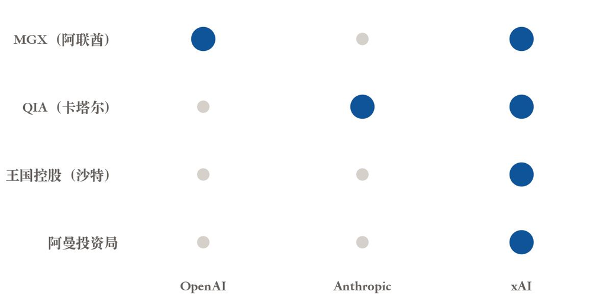

*来源：QIA新闻室（Anthropic）；公司披露；Bloomberg；媒体 | 注：实心点=已披露的持股或融资轮参与；均为少数、非控股权益。*

在这些水平入局前沿，同时下了两个注。其一是财务的：模型层将以快于所付价格的速度增值，而在半万亿美元的估值上，这需要极其惊人的未来增长来证成。其二是战略的：少数股权买到的是关系，与那些模型将跑在海湾算力上的实验室的关系，以及一扇望向前沿的窗，多过买到控制权或技术转移。关系这一维度也许比股权更重要。一只已投资OpenAI、并与甲骨文和英伟达共建数据中心的基金，已被编织进同一个生态，这有助于确保芯片、模型与人才。但对一家美国总部实验室的少数股权，是对前沿的敞口，而非对它的拥有，它并不把海湾从租用者推上构建者的台阶。这一局限引出下一章考察的约束。

图 17: 海湾基金在高估值入局前沿：OpenAI 5000亿、Anthropic 3800亿、xAI 2000亿美元

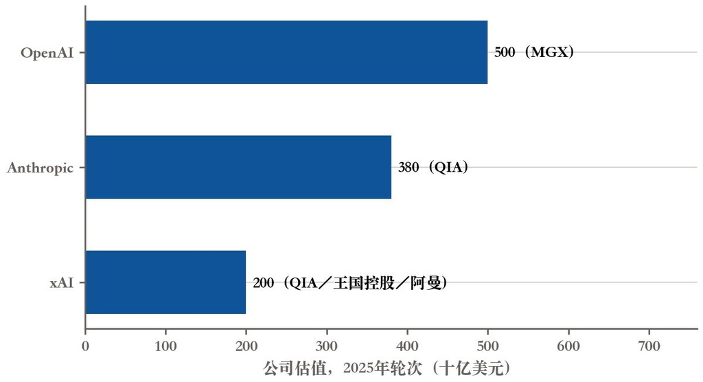

*来源：QIA新闻室（Anthropic G轮）；Bloomberg；Anthropic；媒体 | 注：估值为相应GCC投资者参与的2025年轮次的头条数字。*

# 5 约束：芯片获取与监管的天花板

## 5.1 算力的获取由域外设定

海湾沿价值链的攀升，在芯片层撞上一道硬天花板，而这道天花板是监管性的，而非财务性的。先进AI芯片受出口管制，海湾能以何种条款购买，由域外而非利雅得或阿布扎比设定。这些条款在2025年反复变动：先进芯片出口管制收紧，一套分级获取框架出台后又被撤销，随后是一波海湾芯片协议，到2025年底先进芯片在特定条件下获准出口至G42与Humain (Carnegie Endowment 2025年; CNBC 2025年c)。图 18 追溯了这一序列。对投资者而言，相关的教训是结构性的、也令人警醒：海湾AI建设最重要的实物投入，由一项它不设定、且已被证明在一年之内就会变动的政策所支配。

图 18: 美国芯片出口规则2025年多次摇摆；获取权是海湾唯一无法自定的变量

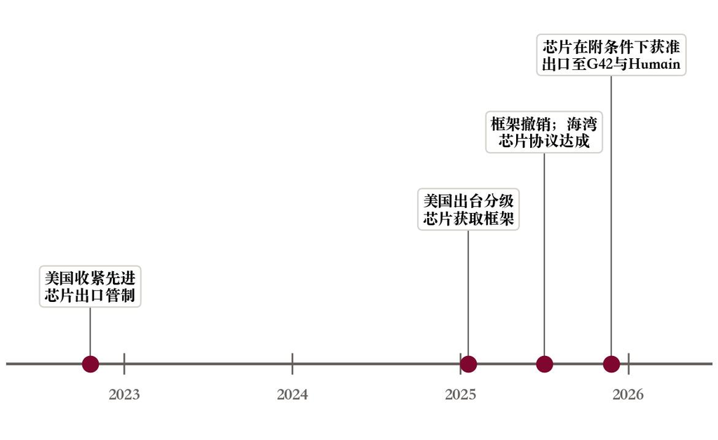

*来源：Carnegie国际和平基金会；CSIS；CNBC（出口政策报道） | 注：精选监管里程碑；2025年的变动先开放、后附条件地限定了海湾AI运营方的先进芯片获取。*

这种波动本身，是独立于政策方向的风险。一项以十年为期规划的容量建设，依赖以数年为期排定的芯片交付，而一个能在数月内收紧或放松的监管机制，给每一个项目融资模型注入了不确定性。即便是有利的规则，只要可被修订，就会抬高那些假定持续获取的项目的资本成本。这正是为何评估海湾芯片协议的分析者强调，这些协议的价值不仅取决于授予的数量，也取决于获取的持久性与附加条件 (Carnegie Endowment 2025年)。

## 5.2 获取的代价：附加在先进芯片上的条件

获取是一桩交易，而条款与数量同样重要。为换取先进算力、超大规模云合作，以及全球AI基础设施枢纽的公认地位，海湾接受了一系列条件：安全与报告要求、经批准运营方与数据管控规则、供应链与美国厂商对齐，以及按年设上限且可续期的配额 (Carnegie Endowment 2025年; CSIS 2025年)。图 19 把所得与条件并置。这里的措辞有意偏向务实而非政治：对投资者而言，重要的事实是芯片层按域外设定的条款提供，而这正是算力主权的上限所在。

图 19: 先进芯片获取是一桩交易：以能力换条件

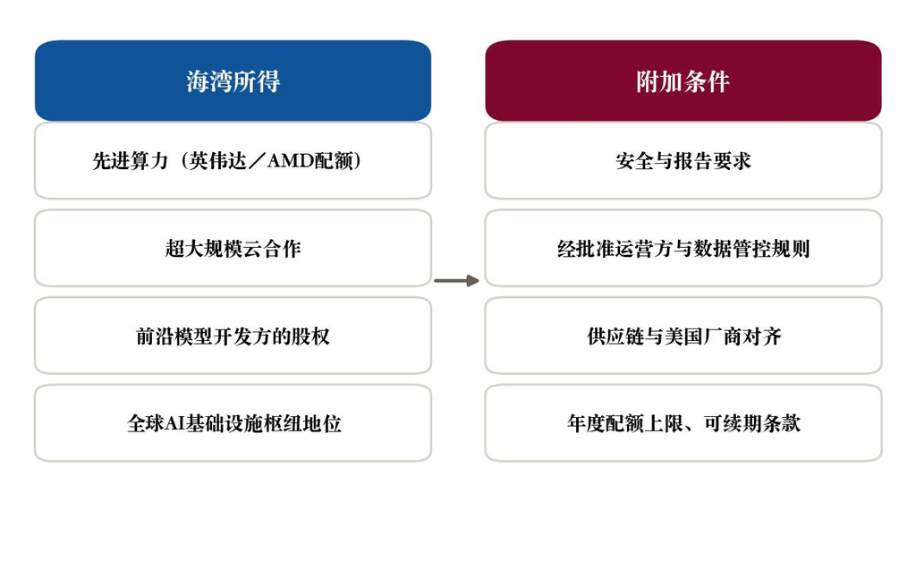

*来源：Carnegie国际和平基金会；CSIS；大西洋理事会；出口政策报道 | 注：示意图；芯片层的获取受域外设定的条款约束，这正是算力主权的上限所在。*

这些条件重塑了整桩建设的风险面貌。一项运行在按年续期的境外配额之上、附带经批准运营方规则与报告义务的数据中心业务，与一项建立在自有或本土所获供给之上的业务，是不同的资产。它的延续取决于维持这些条件，其中包括与供应芯片的厂商生态保持对齐。对那些此前在多个地区建立科技关系的海湾运营方而言，满足这些条件意味着向美国厂商栈重新定向，G42是海湾运营方为换取先进算力之门而重组合作关系的最显眼例子。这在受管制的高技术贸易中并不罕见，但它是芯片层就目前而言仍是一级租用而非拥有的具体机制。

## 5.3 主权的天花板：拥有基础设施、租用前沿

前沿模型层比芯片更遥不可及。领先的基础模型绝大多数在海湾之外构建：按一项被广泛引用的统计，2025年美国生产约40个大型基础模型，中国约15个，欧盟约3个 (Atlantic Council 2025年; Middle East Institute 2025年)。没有任何总部在海湾的实验室跻身领先之列。图 20 显示了这一分布。海湾以投资者与东道主身份参与这一层，提供资本与算力，但不是前沿模型的构建者，而构建一个前沿模型主要不是钱的问题。它需要专业人才的聚集、积累的研究，以及反复的规模化，而这些迄今单凭资本无法迅速买到。

图 20: 前沿模型层在海湾之外：美国约40个，中国约15个，欧盟约3个

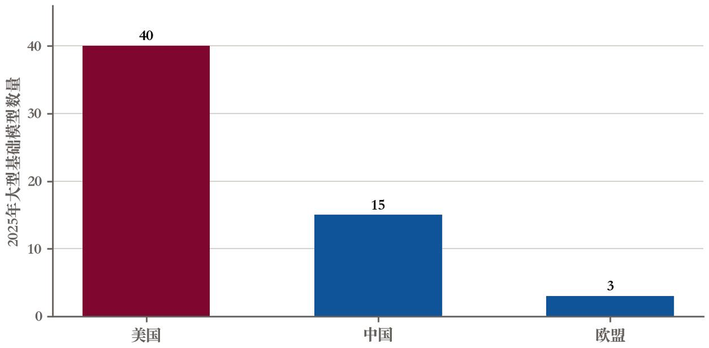

*来源：大西洋理事会；斯坦福AI指数式统计（近似） | 注：海湾无任何总部级前沿模型开发方；海湾以投资者与东道主身份参与，而非构建者。*

把芯片约束与模型约束相加，得出本报告的核心结构性发现，它可被精确陈述。海湾能够拥有能源与算力这两级下层，那里它的比较优势是真实的。它能够通过配额与股权，买到对芯片与模型这两级上层的少数敞口。但就现有证据看，它无法拥有先进硅片与前沿模型这两层，而正是这两层赋予真正的技术自主。这就是主权的天花板。它并不使这套战略不明智；为世界托管算力、为前沿出资，也许是一桩相当不错的生意。但它确实意味着，海湾的AI地位，是融入一套以美国为锚的栈，而非独立于它，而这种融入，是整桩事业的恒定前提。

# 6 这笔赌注划算吗：回报与可持续性的裁决

## 6.1 多头理由：押注时代最重要的技术的期权价值

支持这场转向的最有力论据是，AI重要到不容置身事外，而海湾为之带来了真实的优势。PwC估计，到2030年AI可为中东经济增加约3200亿美元，相当于区域GDP的11%，其中沙特获益1350亿美元，即其GDP的12.4%，阿联酋960亿美元，即13.6% (PwC 2025年)。图 21 显示了分布；沙特与阿联酋合计占区域预测总量的70%以上。麦肯锡同样估计，生成式AI每年可为海湾经济增加210至350亿美元，叠加在传统来源带来的更大收益之上，并指出海湾机构采用AI工具的比例高于全球平均 (McKinsey 2025年)。

图 21: 多头情景：到2030年AI或为中东增加3200亿美元，沙特与阿联酋领跑

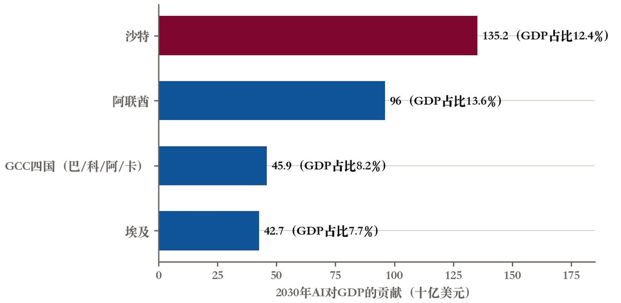

*来源：PwC《AI在中东的潜在影响》 | 注：PwC情景估算；沙特1352亿美元（GDP的12.4%）与阿联酋960亿美元（13.6%）合计占区域总量逾70%。*

这些预测应被当作情景估算而非预报，但其背后海湾的具体优势是实在的。它拥有用于数据中心的廉价能源与土地，拥有能吸纳长回收期而无赎回压力的耐心资本池，并自2025年起拥有谈判得来的先进芯片获取权，以及与领先实验室和超大规模云厂商的合作。对一个寻求摆脱石油依赖的地区而言，AI基础设施提供了早先多元化押注（如旅游或本土制造）所不具备的东西：一种可全球交易的服务，即算力，能从区域之外的客户处赚取外汇收入。按此解读，这场转向是把一项真实比较优势，理性地部署到时代决定性增长行业中，而拥有一个桌边席位的期权价值，即便个别项目令人失望也值回所付的代价。

## 6.2 空头理由：循环融资与不确定的回报

反对的理由是财务性的，它从AI建设如何筹资讲起。全球建设的大部分，通过一张环环相扣的交易网络筹资，同一笔资本以芯片、云承诺与股权的形式反复流转，观察者把这一模式比作上世纪90年代末科技繁荣中的供应商融资 (Bloomberg 2026年)。图 22 勾勒了这张网络以及海湾在其中的位置。海湾资本通过对OpenAI的股权、与甲骨文在Stargate上的合资、以及向英伟达的芯片采购，被接入这些资金流，这意味着它暴露于同样的循环性：倘若整个生态的AI收入不及预期，损失可沿环环相扣的资产负债表连锁传导，而非局限于单个项目。

图 22: 海湾资本嵌入AI的循环融资网络：同一笔钱以芯片、云与股权反复流转

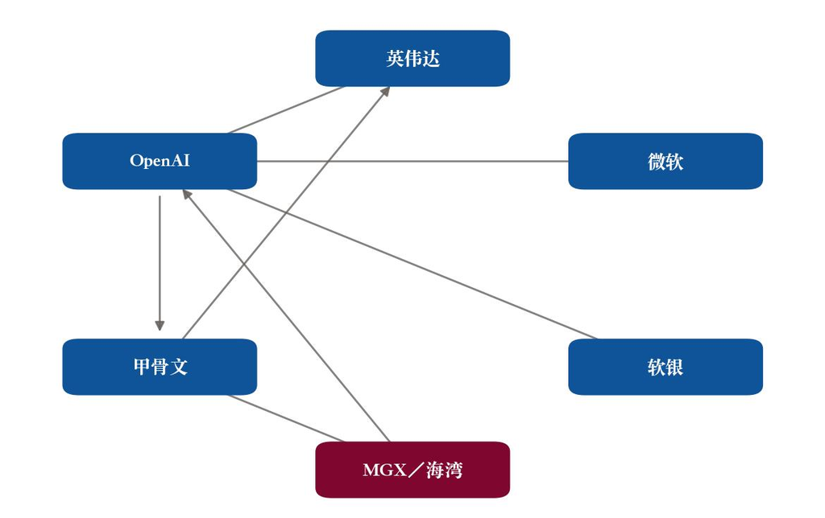

*来源：Bloomberg（AI循环交易）；公司披露；作者梳理 | 注：主要资金流示意，非穷举；循环性在AI收入不及预期时放大连锁损失风险。*

回报本身仍未被证实。这些基金不披露其AI投资的分部回报，因此任何关于盈利的说法都是推断而非衡量。数据中心的底层经济性并不确定：容量的建设远跑在已证实的需求之前，分析者已警示，若建设跑过使用，将面临利用率不足与利润微薄的风险 (Gulf International Forum 2025年)。海湾买入的前沿实验室大多仍在亏损，以当下的现金消耗换取未来盈利的承诺。IMF于2026年警告，随着金融脆弱性上升，区域风险可能放缓AI投资，而2026年初的报道已开始用恰恰这些压力检验海湾的数据中心雄心 (Semafor 2026年)。这一切都不能证明这笔赌注会失败。但它确实意味着，这笔赌注建立在尚不存在的预期未来现金流之上，而这正是期权而非收入流的定义，而期权可能一文不值地到期。

## 6.3 集中度与财政敞口：赌注押在石油与少数名字上

这笔赌注还很集中，这放大了上行与下行两端。少数大额交易占去了相当部分的在险资本：PIF以550亿美元收购艺电（EA），MGX 400亿美元收购Aligned，以及一组数十亿美元级的基础设施协议，包括Humain的AWS与AirTrunk交易和NEOM的DataVolt项目 (CNBC 2025年a)。图 23 给出最大披露交易的排名。集中是把双刃剑。它让海湾在标志性资产中握有真实的控股或锚定头寸，这是战略吸引力的一部分，但它把结果系于少数名字与行业，因此其中一两个失足，便可能拖累整个计划。

图 23: 资本集中于少数大额交易，以EA（550亿）与Aligned（400亿美元）为首

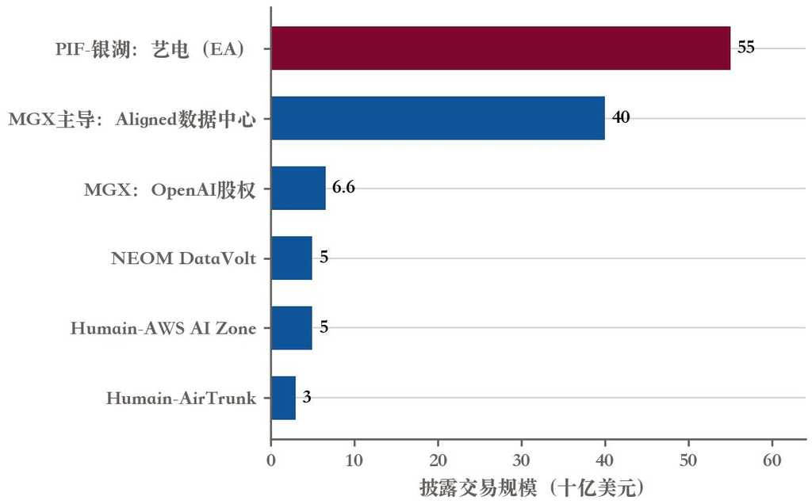

*来源：公司披露；Bloomberg；CNBC；媒体 | 注：EA为游戏并购（PIF／银湖），作为顶级主权科技交易纳入；其余为AI基础设施交易。*

把已宣布的意向与已落实的资本分开，至关重要，因为二者之间的缺口，正是这场转向表面规模的很大一部分所在之处。2025年那一轮美湾系列协议的头条承诺非常庞大，与沙特相关约6000亿美元，卡塔尔2430亿美元，阿联酋2000亿美元，但这些是跨多年、多行业的承诺，而非已落实的AI资本 (Rest of World 2025年)。图 24 显示了头条数字，应被当作雄心的上限，而非已花费金额的衡量。迄今已落实的部署仅为承诺总额的一小部分，而把二者等同，正如许多报道隐含所为，会实质性地高估这场转向。有纪律的数字，是本报告前文那些，即660亿美元的单年主权AI部署与具体的已成交交易，而非万亿美元的承诺头条。

图 24: 约1.0万亿美元的海湾承诺头条是意向，而非已投资本

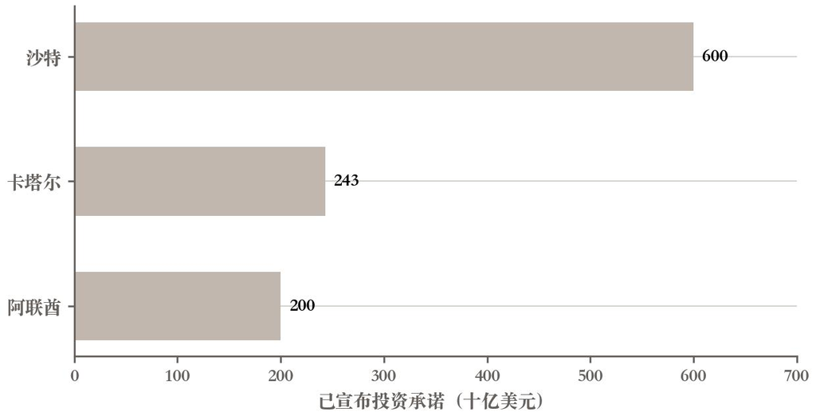

*来源：Axios；Reuters；Euronews；Rest of World（2025年5月美湾系列协议） | 注：跨多年、多行业的已宣布承诺，非已落实或已投AI资本；迄今已落地部署仅为很小一部分。*

交易集中之下，是第二章确立的财政敞口。筹资基础仍对石油敏感，而IMF的压力情景，即油价负向冲击把沙特赤字推过GDP的10%，将收紧的恰恰是为AI建设筹资的那些预算 (IMF 2025年)。换言之，这笔赌注是双重杠杆的：押在回报未被证实的AI资产上，也押在出资方无法掌控的油价上。正是这一组合，使裁决是有条件的而非干净利落的。

## 6.4 裁决：作为战略站得住脚，作为投资尚未被证实

权衡两方理由，这场转向最好被理解为一项战略期权，而非一笔常规投资，而这一区别并非措辞游戏。作为战略与多元化，它站得住脚：海湾正把一项真实的比较优势，廉价能源与耐心资本，部署到时代最重要的技术中，且以给予它真实资产、外汇收入潜力，以及横跨全球AI生态之关系的条款进行。一个具有数十年视野、又需建设后石油经济的主权投资者，比一只追逐短期回报的私人基金，更有理由支付这笔期权溢价。

然而，作为以风险调整后回报衡量的投资，它尚未被证实。现金流尚不存在，融资是循环的，资本集中于少数名字，筹资基础对石油敏感。这是方向性判断，并如此呈现，而非可衡量的回报，因为衡量回报所需的数据并未披露。诚实的结论是：这场转向以站得住脚的战略价格，为海湾买到了在AI经济中的一个地位，却把这一地位能否赚回其资本成本的问题悬而未决。战略成功还是财务失望这两种解读中哪一种胜出，取决于末章列出的变量。

# 7 结论与展望

## 7.1 一台带封顶天花板的主权AI机器

在大约24个月里，海湾建起了一台协同、垂直整合的主权AI资本机器。它设立国家冠军、签约数吉瓦算力、谈成芯片获取、并买入前沿实验室，向AI投入的主权资本多过任何其他地区。这一成就是真实的，它反映出廉价能源、耐心资本与果断的国家主导等少有其他地区能匹敌的优势。它的局限也同样真实。这台机器拥有价值链底层、租用顶层；它对决定性的芯片与模型层的获取，按域外设定的条款授予；其财务回报建立在尚未兑现的回报之上，背景是一个正在收紧为建设筹资之预算的、更软的油价前景。海湾为自己买到了在AI经济中的一个席位。它尚未买到在其中的自主，也尚未证明这个席位会回本。

成就真实、天花板封顶这一双重结论，是诚实的概括。它既抵制把承诺当作已部署万亿美元的吹捧，也抵制把整桩努力当作泡沫期虚荣项目的轻蔑。海湾对成为全球AI基础设施不可或缺的一环，下了一个认真、资源充足、且自洽的赌注。这一赌注将复利成长为后石油经济的支柱，还是沉淀为一项从未真正回本的昂贵期权，目前尚无法从证据中判定，而在任一方向上断言确定，都会夸大数据所能支撑的程度。

## 7.2 2026年起需盯的五个变量

这笔赌注能否回本，将在未来数年通过五个变量显现。图 25 列出了它们。前两个基本不在海湾掌控之内：芯片出口规则的稳定性，单一监管周期即可收紧，以及相对盈亏平衡的油价，它决定出资方有多大空间。后三个部分在其掌控之内：已公布的数据中心容量能否建成并以健康利润被用起来，而非闲置；对前沿实验室的少数股权能否转化为真正的能力，而不止是财务敞口；以及这些基金对少数大额交易与名字的集中度会变得多高。

图 25: 五个变量将决定海湾的AI赌注能否回本

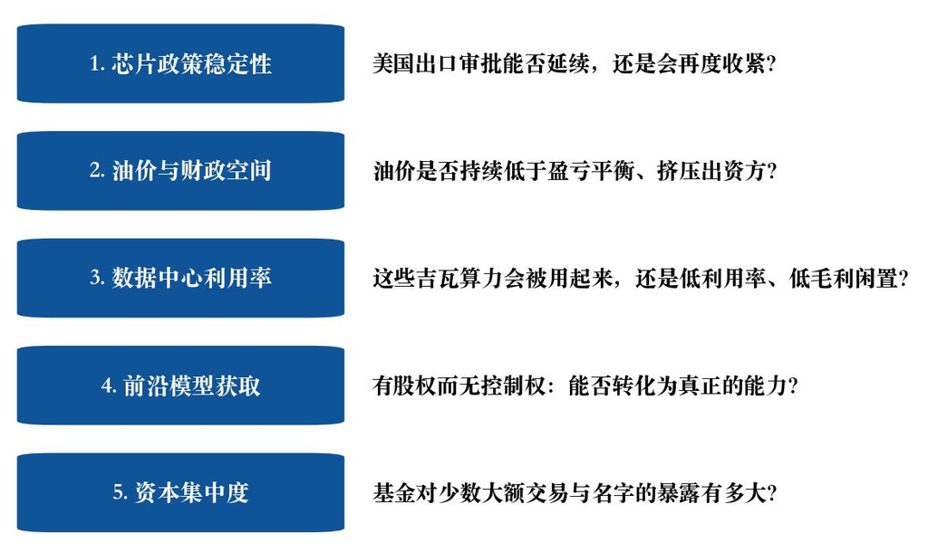

*来源：作者综合；Semafor；IMF | 注：2026年起的监测框架；前两项基本不在海湾掌控之内，后三项部分可控。*

图 26: 赌注能否回本，取决于海湾仅部分掌控的两个变量：芯片获取与油价

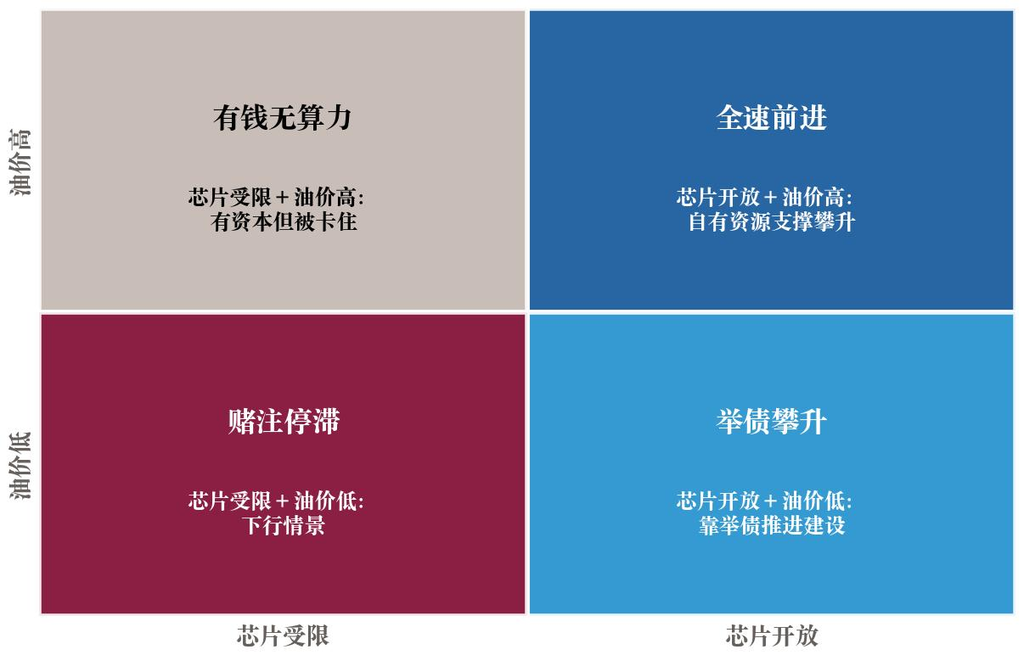

*来源：作者框架 | 注：情景示意矩阵；海湾既不设美国出口政策，也不定油价，二者共同界定回报区间。*

这，最终是本报告的核心要点。海湾以非凡的速度与规模建起了一台主权AI机器，调动逾3万亿美元资本与一套协同的机构栈，去支撑一套自洽的战略。然而，将最决定其回报的两个因素，先进芯片获取与油价，恰是它最不能掌控的两个。这场转向已为海湾争得在AI经济中的一席之地。在这一席之地上赚取回报，是另一个问题，而其答案部分握在他人手中。

# 8 参考文献

Analysys Mason. 2026年. *Accelerated investment in AI data centres in the GCC will reach USD5-7 billion in 2026*. Analysys Mason. https://www.analysysmason.com/about-us/news/predictions-2026/prediction-ai-investment-gcc/.

Atlantic Council. 2025年. *AI geopolitics and the global foundation-model landscape*. Atlantic Council. https://www.atlanticcouncil.org/programs/geotech-center/.

Bloomberg. 2025年. *AI Investments: Blue Owl, xAI Deals Solidify QIA’s $500 Billion US Pledge*. Bloomberg. https://www.bloomberg.com/news/articles/2025-09-29/ai-investments-blue-owl-xai-deals-solidify-qia-s-500-billion-us-pledge.

Bloomberg. 2026年. *AI Circular Deals: How Microsoft, OpenAI and Nvidia Keep Paying Each Other*. Bloomberg. https://www.bloomberg.com/graphics/2026-ai-circular-deals/.

Carnegie Endowment. 2025年. *How to Gauge Whether the AI Chip Deals With Gulf Countries Are Any Good*. Carnegie Endowment for International Peace. https://carnegieendowment.org/emissary/2025/05/ai-chip-trump-gulf-uae-saudi-security-risk-good-deal.

CNBC. 2025年a. *Abu Dhabi’s MGX investments in OpenAI, TikTok and crypto*. CNBC. https://www.cnbc.com/2025/10/15/abu-dhabis-mgx-investments-in-trump-crypto-tiktok-openai-.html.

CNBC. 2025年b. *Saudi AI firm Humain is pouring billions into data centers. Will it pay off?* CNBC. https://www.cnbc.com/2025/08/27/saudi-arabia-wants-to-be-worlds-third-largest-ai-provider-humain.html.

CNBC. 2025年c. *US approves AI chip exports to Gulf tech giants*. CNBC. https://www.cnbc.com/2025/11/20/us-approves-ai-chip-exports-to-gulf-after-saudi-crown-prince-visit.html.

CSIS. 2025年. *If Compute Is the New Oil, War in the Gulf Significantly Raises the Stakes*. Center for Strategic and International Studies. https://www.csis.org/analysis/if-compute-new-oil-war-gulf-significantly-raises-stakes.

DataCenterDynamics. 2025年. *US and UAE plan to build 5GW AI data center campus, run by G42 and US hyperscalers*. DataCenterDynamics. https://www.datacenterdynamics.com/en/news/us-and-uae-plan-to-build-5gw-ai-data-center-campus-run-by-g42-and-american-hyperscalers/.

DataCenterDynamics. 2026年. *Humain and Infra set up $1.2bn financing package for 250MW of data center space*. DataCenterDynamics. https://www.datacenterdynamics.com/en/news/.

Emirates NBD Research. 2025年. *GCC: Lower oil price will weigh on budgets*. Emirates NBD Research. https://www.emiratesnbdresearch.com/en/articles/gcc-lower-oil-price-will-weigh-on-budgets.

Global SWF. 2025年. *Sovereign Wealth Fund Rankings (July 2025)*. Global SWF; reported via Gulf Business and Zawya. https://globalswf.com/ranking.

Global SWF. 2026年. *2026 Annual Report: Sovereign Wealth and Public Pension Funds*. Global SWF. https://globalswf.com/reports.

Gulf International Forum. 2025年. *Gulf AI Infrastructure: Examining the Business and Economic Case*. Gulf International Forum. https://gulfif.org/gulf-ai-infrastructure-examining-the-business-and-economic-case/.

IMF. 2025年. *Saudi Arabia: 2025 Article IV Consultation, Staff Report (Country Report No. 25/223)*. International Monetary Fund. https://www.imf.org/-/media/files/publications/cr/2025/english/1sauea2025001-source-pdf.pdf.

McKinsey. 2025年. *Generative AI in the GCC: economic potential*. McKinsey & Company. https://www.mckinsey.com/.

MGX. 2025年. *MGX Fund Management: mandate and partnerships*. MGX; company disclosures. https://mgx.ae/.

Middle East Institute. 2025年. *AI, the Gulf, and the US: A Primer*. Middle East Institute. https://mei.edu/report/ai-the-gulf-and-the-us-a-primer/.

NVIDIA. 2025年. *HUMAIN and NVIDIA Announce Strategic Partnership to Build AI Factories in Saudi Arabia*. NVIDIA Newsroom. https://nvidianews.nvidia.com/news/humain-and-nvidia-announce-strategic-partnership-to-build-ai-factories-of-the-future-in-saudi-arabia.

PwC. 2025年. *The Potential Impact of AI in the Middle East*. PwC Middle East. https://www.pwc.com/m1/en/publications/potential-impact-artificial-intelligence-middle-east.html.

QIA. 2025年. *QIA Increases Investment in Anthropic Through $30 Billion Series G Financing*. Qatar Investment Authority Newsroom. https://www.qia.qa/en/Newsroom/Pages/default.aspx.

Rest of World. 2025年. *Middle East trip sparks $2.2T in tech and chip deals*. Rest of World. https://restofworld.org/2025/trump-middle-east-trip-ai-chip-tech-deals/.

Semafor. 2025年. *PIF’s AI unit HUMAIN has already sold out its data center capacity*. Semafor. https://www.semafor.com/article/08/27/2025/pifs-ai-unit-has-already-sold-out-its-data-center-capacity.

Semafor. 2026年. *Data centers under fire test Gulf sovereign AI ambitions*. Semafor. https://www.semafor.com/article/04/13/2026/data-centers-under-fire-test-gulf-sovereign-ai-ambitions.

The National. 2025年. *Saudi’s PIF raises 2030 assets target to $2.67 trillion after exceeding last year’s goal*. The National. https://www.thenationalnews.com/business/2025/04/27/saudis-pif-raises-2030-target-to-267-trillion-after-exceeding-last-years-goal/.